# SSC2022-Competition

Eralda Gjika

# Source of information and data:

https://ssc.ca/en/case-study/developing-a-physician-performance-model-critical-care-assessing-quality-and-value

# Information on dataset and variables

Physician characteristics “DocID” Physician ID “M1” Indicates how many sites is this physician works at “M2” Does this physician have a leadership role in the department? “M3” Indicates the rank of a physician (senior/junior) “M4” Average overall score from survey in 2016 “M5” Resident evaluation ranking group in 2016 “M6” Sex “M7” In what domain has the physician received training? “M8” Age >= 50 “M9” Education

Patient Characteristics “DocID” Physician ID “PtID” Patient ID “P1” Age >= 60 “P2” Was an emergent or rapid response such as an operation needed at admission? “P3” To which ICU department was the patient admitted? “P4” Charlson comorbidity scoring group “P5” APACHE-II score at admission “P6” SOFA score at admission “P7” Sex “P8” Status at ICU discharge “P9” ICU length of stay “P10” What was the primary diagnosis? SOFA trajectory “PtID” Patient ID “day” Day of ICU stay (limited to 20 days) “SOFA” SOFA score Survey evaluation “Q1” Medical Expert Functions effectively as a consultant to provide optimal ethical and patient centered medical care “Q2” Medical Expert Demonstrates proficient and appropriate use of procedural skills both diagnostic and therapeutic “Q3” Medical Expert Follows appropriate infection prevention practices and serves as a role model for others “Q4” Advocacy Responds to individual patient health needs and issues as part of patient care “Q5” Scientific knowledge Is up to date on current medical knowledge and applies that knowledge in providing patient care and to promote the learning of others “Q6” Professionalism Is courteous and respectful in interactions including those that are demanding or stressful “Q7” Professionalism Demonstrates honesty and integrity “Q8” Professionalism Is approachable and responsive to concerns raised “Q9” Professionalism Responds to pages and requests in a prompt manner “Q10” Communication Communicates respectfully with other allied health professionals “Q11” Communication Provides clear explanations in response to patients and families questions “Q12” Communication Listens effectively “Q13” Communication Accepts feedback graciously “Q14” Communication Provides clear understandable instructions “Q15” Collaboration Establishes good relationships with peers and other members of the health care team “Q16” Collaboration Works constructively within the health care team to optimize patient care “Q17” Collaboration Respects the professional knowledge skills and contributions of other allied health professionals “Q18” Collaboration Takes responsibilty for actions without blaming others “Q19” Management Demonstrates strong leadership skills “Q20” Management Effectively manages the team during acute resuscitation of critically ill patients “Q21” Management Conducts daily bedside rounds in an efficient manner while still balancing teaching responsibilities “Q22” Management Makes efficient use of their time to optimize professional performance “Q23” Overall Score overall score “DocID” Physician who a participant evaluated “position” Participant’s position

# Before you start

## Multiplot function for ggplot which will be used latter

(just run it)

```r
# Multiple plot function
#
# ggplot objects can be passed in ..., or to plotlist (as a list of ggplot objects)
# - cols:   Number of columns in layout
# - layout: A matrix specifying the layout. If present, 'cols' is ignored.
#
# If the layout is something like matrix(c(1,2,3,3), nrow=2, byrow=TRUE),
# then plot 1 will go in the upper left, 2 will go in the upper right, and
# 3 will go all the way across the bottom.
#
multiplot <- function(..., plotlist=NULL, file, cols=1, layout=NULL) {
  library(grid)

  # Make a list from the ... arguments and plotlist
  plots <- c(list(...), plotlist)

  numPlots = length(plots)

  # If layout is NULL, then use 'cols' to determine layout
  if (is.null(layout)) {
    # Make the panel
    # ncol: Number of columns of plots
    # nrow: Number of rows needed, calculated from # of cols
    layout <- matrix(seq(1, cols * ceiling(numPlots/cols)),
                    ncol = cols, nrow = ceiling(numPlots/cols))
  }

 if (numPlots==1) {
    print(plots[[1]])

  } else {
    # Set up the page
    grid.newpage()
    pushViewport(viewport(layout = grid.layout(nrow(layout), ncol(layout))))

    # Make each plot, in the correct location
    for (i in 1:numPlots) {
      # Get the i,j matrix positions of the regions that contain this subplot
      matchidx <- as.data.frame(which(layout == i, arr.ind = TRUE))

      print(plots[[i]], vp = viewport(layout.pos.row = matchidx$row,
                                      layout.pos.col = matchidx$col))
    }
  }
}
```

# Importing data

Import the dataset from a file saved in your computer.

```r
library(readxl)
df_doctors_v20220321<-read_excel("SSC 2022-Canada/df_doctors_v20220321.xlsx")
#View(df_doctors_v20220321)

df_eval360_v20220321 <- read_excel("SSC 2022-Canada/df_eval360_v20220321.xlsx")
#View(df_eval360_v20220321)

df_patients_v20220321 <- read_excel("SSC 2022-Canada/df_patients_v20220321.xlsx")
#View(df_patients_v20220321)

df_traj_v20220321 <- read_excel("SSC 2022- Canada/df_traj_v20220321.xlsx")
#View(df_traj_v20220321)
```

# Random Forest variable importance

# Variable Importance

Reference: https://rpubs.com/minma/cart_with_rpart http://www.di.fc.ul.pt/~jpn/r/tree/tree.html

Libraries used:

```r
library(dplyr)
library(corrplot)
library(caret)
library(glm2)
library(e1071)
library(randomForest)
library(purrr)
library(tidyr)
library(vtable)
library(ROSE)
library(lmtest)
library(skimr)
library(DataExplorer)
library(forcats)
library(rpart.plot)
library(ranger)
library(mlr)
library(class)
library(gmodels)
# library(binaryLogic)
```

```r
library(rcompanion)
library(olsrr)
library(gridExtra)
library(reshape)
library(Boruta)
```

# Missing data information

This are some consideration on which variables should be taken into account when looking at the dataset and target variables related to physician performance.

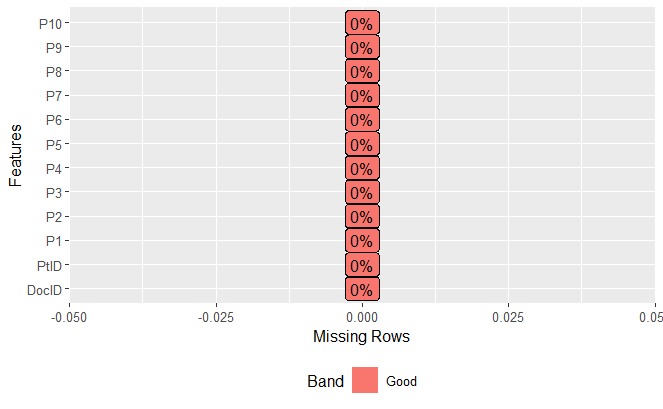

```r
plot_missing(df_patients_v20220321,) # this may be used for each of the three dataset
```

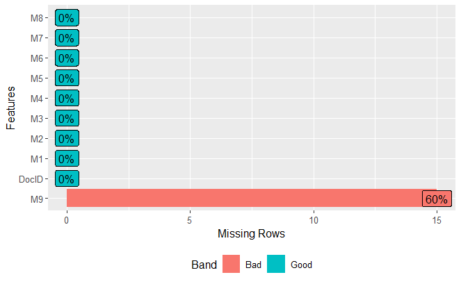

```r
plot_missing(df_doctors_v20220321,) # this may be used for each of the three dataset
```

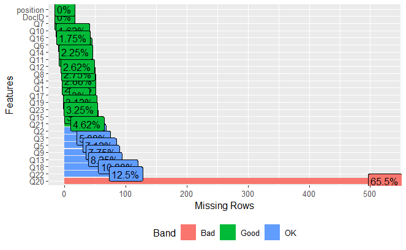

```r
plot_missing(df_eval360_v20220321,) # this may be used for each of the three dataset
```

M9 and Q20 are not with full info so they may be not considered.

## Variable importance for M4 in the physician dataset.

```r
boruta_output <- Boruta(M4~., data=df_doctors_v20220321[,-c(1,10)], doTrace=0)
boruta_signif <- getSelectedAttributes(boruta_output, withTentative = TRUE)
print(boruta_signif)
```

```
[1] "M3" "M6" "M7"
```

```r
# Do a tentative rough fix
roughFixMod <- TentativeRoughFix(boruta_output)
boruta_signif <- getSelectedAttributes(roughFixMod)
print(boruta_signif)
```

```
[1] "M7"
```

```r
# Variable Importance Scores
imps <- attStats(roughFixMod)
imps2 = imps[imps$decision != 'Rejected', c('meanImp', 'decision')]
head(imps2[order(-imps2$meanImp), ])  # descending sort
```

|  | meanImp | decision |
| --- | --- | --- |
| M7 | 7.615072 | Confirmed |

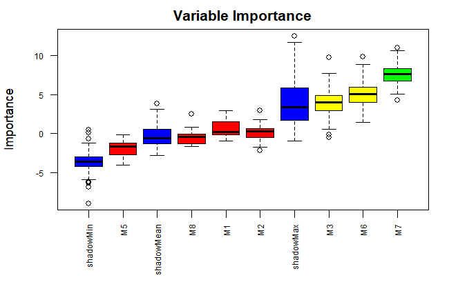

```r
# Plot variable importance
plot(boruta_output, cex.axis=.7, las=2, xlab="", main="Variable Importance")
```

# Random Forest

```r
set.seed(0)
model_rf <- ranger(M4~., data=df_doctors_v20220321[,-c(1,10)], mtry = 2, num.trees = 500, write.forest=TRUE, importance = "permutation")
```

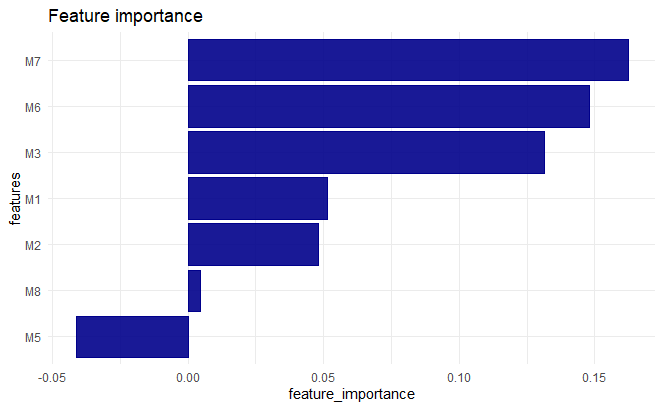

```r
p1<-data.frame(variables = names(importance(model_rf, method = "janitza")),           feature_importance = importance(model_rf, method = "janitza")) %>%
  ggplot(aes(x = feature_importance, y = reorder(variables, X = feature_importance))) +
    geom_bar(stat = "identity",  alpha=0.9, col="darkblue", fill="darkblue") +
    labs(y = "features", title = "Feature importance") +
    theme_minimal(base_size = 10)
p1
```

To better understand and consolidate the variable importance we also did some extra graphs.

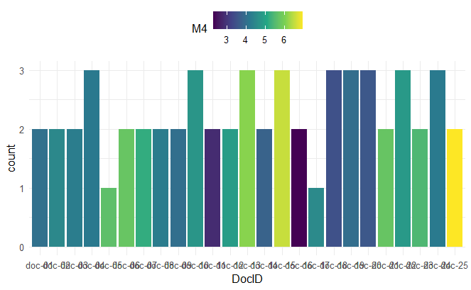

```r
ggplot(df_doctors_v20220321) +
  aes(x = DocID, fill = M4, weight = M5) +
  geom_bar() +
  scale_fill_viridis_c(option = "viridis", direction = 1) +
  theme_minimal() +
  theme(legend.position = "top")
```

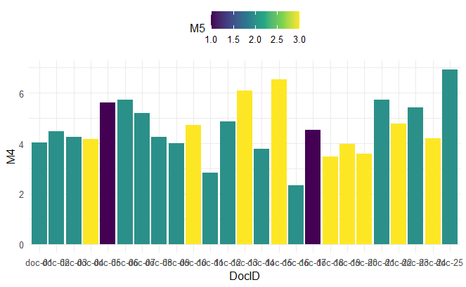

```r
ggplot(df_doctors_v20220321) +
  aes(x = DocID, fill = M5, weight = M4) +
  geom_bar() +
  labs(y="M4")+
  scale_fill_viridis_c(option = "viridis", direction = 1) +
  theme_minimal() +
  theme(legend.position = "top")
```

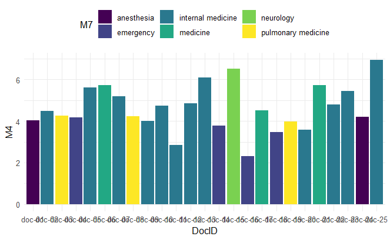

```r
ggplot(df_doctors_v20220321) +
  aes(x = DocID, fill = M7, weight = M4) +
  geom_bar() +
    labs(y="M4")+
  scale_fill_viridis_d(option = "viridis", direction = 1) +
  theme_minimal() +
  theme(legend.position = "top")
```

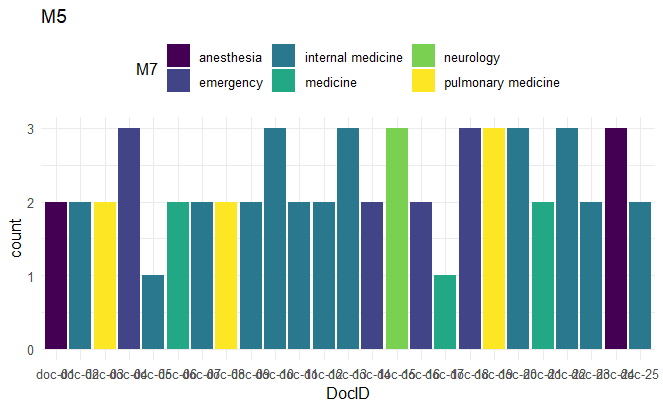

```r
ggplot(df_doctors_v20220321) +
  aes(x = DocID, fill = M7, weight = M5) +
  geom_bar() +
  scale_fill_viridis_d(option = "viridis", direction = 1) +
  labs(title = "M5") +
  theme_minimal() +
  theme(legend.position = "top")
```

## Patient dataset graphs

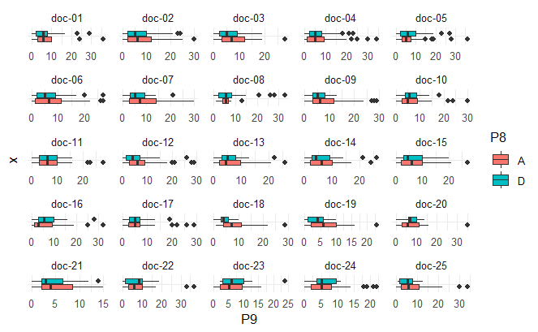

```r
ggplot(df_patients_v20220321) +
  aes(x = "", y = P9, fill = P8) +
  geom_boxplot() +
  scale_fill_hue(direction = 1) +
  coord_flip() +
  theme_minimal() +
  facet_wrap(vars(DocID), scales = "free")
```

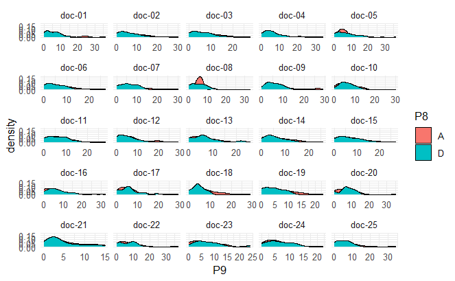

```r
ggplot(df_patients_v20220321) +
  aes(x = P9, fill = P8) +
  geom_density(adjust = 1L) +
  scale_fill_hue(direction = 1) +
  theme_minimal() +
  facet_wrap(vars(DocID), scales = "free_x")
```

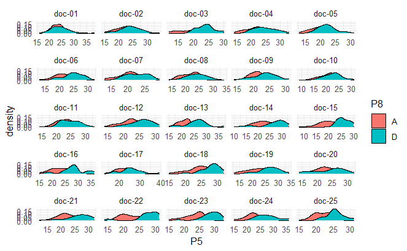

```r
ggplot(df_patients_v20220321) +
  aes(x = P5, fill = P8) +
  geom_density(adjust = 1L) +
  scale_fill_hue(direction = 1) +
  theme_minimal() +
  facet_wrap(vars(DocID), scales = "free_x")
```

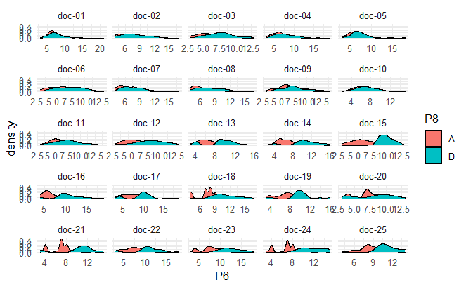

```r
ggplot(df_patients_v20220321) +
  aes(x = P6, fill = P8) +
  geom_density(adjust = 1L) +
  scale_fill_hue(direction = 1) +
  theme_minimal() +
  facet_wrap(vars(DocID), scales = "free_x")
```

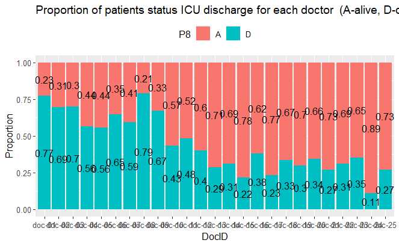

```r
ggplot(df_patients_v20220321, aes(x=DocID, fill=P8)) +
  geom_bar(position="fill") +
  geom_text(
    aes(label=signif(..count.. / tapply(..count.., ..x.., sum)[as.character(..x..)], digits=2)),
    stat="count",
    position=position_fill(vjust=0.5)) +
  labs(y="Proportion")+
  ggtitle("Proportion of patients status ICU discharge for each doctor  (A-alive, D-dead)")+
  theme(legend.position="top")
```

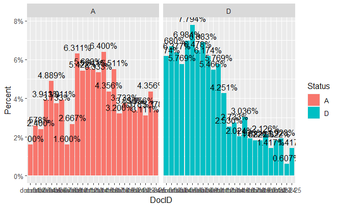

```r
ggplot(df_patients_v20220321, aes(x= DocID,group=P8)) +
    geom_bar(aes(y = ..prop.., fill = factor(P8)), stat="count") +
    geom_text(aes( label = scales::percent(..prop..), y= ..prop.. ), stat= "count", vjust = -.5) +
    labs(y = "Percent", fill="Status") +
    facet_grid(~P8) +
    scale_y_continuous(labels = scales::percent)
```

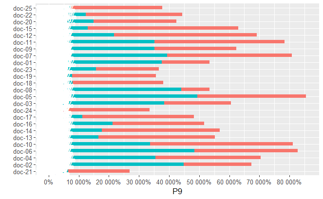

```r
df_patients_v20220321 %>%
  group_by(P8) %>%
  ggplot(aes(y = forcats::fct_reorder(DocID, P9),
             x = P9,
             fill=P8,
             label=scales::percent(P9)))+
  geom_col(width=0.5)+
  theme(legend.position="none")+
  labs(y="",
       x="P9")+
  scale_x_continuous(labels = scales::percent,
                     breaks = scales::pretty_breaks(n = 8))+
  geom_text(nudge_x= -.01,
            color="white",
            size = 5,
            fontface="bold")
```

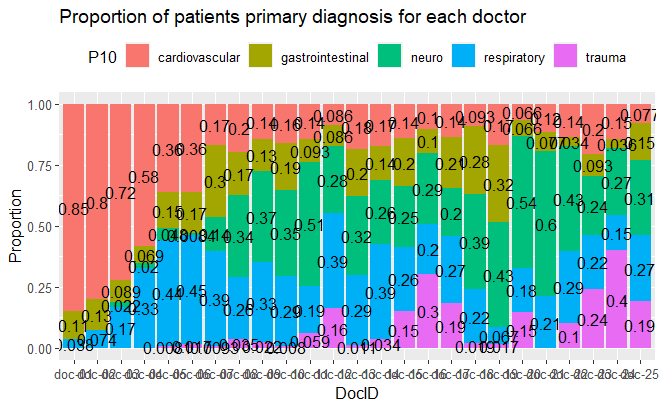

```r
ggplot(df_patients_v20220321, aes(x=DocID, fill=P10)) +
  geom_bar(position="fill") +
  geom_text(
    aes(label=signif(..count.. / tapply(..count.., ..x.., sum)[as.character(..x..)], digits=2)),
    stat="count",
    position=position_fill(vjust=0.5)) +
  labs(y="Proportion")+
  ggtitle("Proportion of patients primary diagnosis for each doctor ")+
  theme(legend.position="top")
```

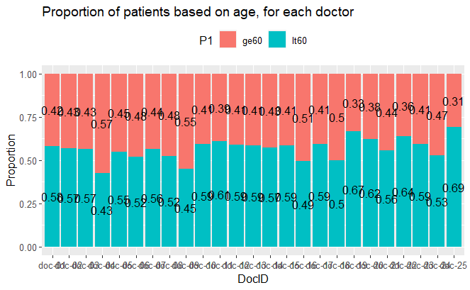

```r
ggplot(df_patients_v20220321, aes(x=DocID, fill=P1)) +
  geom_bar(position="fill") +
  geom_text(
    aes(label=signif(..count.. / tapply(..count.., ..x.., sum)[as.character(..x..)], digits=2)),
    stat="count",
    position=position_fill(vjust=0.5)) +
  labs(y="Proportion")+
  ggtitle("Proportion of patients based on age, for each doctor ")+
  theme(legend.position="top")
```

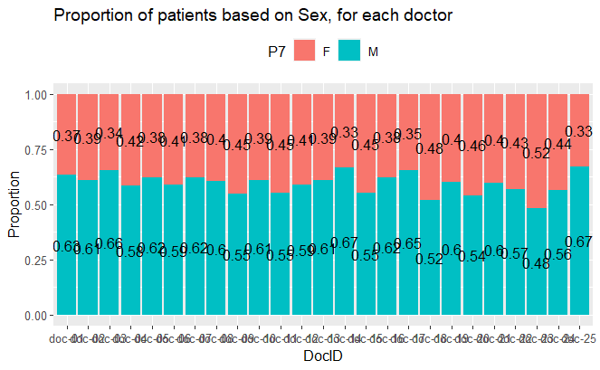

```r
 ggplot(df_patients_v20220321, aes(x=DocID, fill=P7)) +
  geom_bar(position="fill") +
  geom_text(
    aes(label=signif(..count.. / tapply(..count.., ..x.., sum)[as.character(..x..)], digits=2)),
    stat="count",
    position=position_fill(vjust=0.5)) +
  labs(y="Proportion")+
  ggtitle("Proportion of patients based on Sex, for each doctor ")+
  theme(legend.position="top")
```

[output not shown]

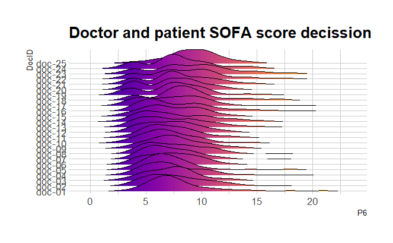

```r
# library
library(ggridges)
library(ggplot2)
library(viridis)
library(hrbrthemes)

# Plot
ggplot(df_patients_v20220321, aes(x = P6, y = DocID, fill = ..x..)) +
  geom_density_ridges_gradient(scale = 3, rel_min_height = 0.01) +
  scale_fill_viridis(name = "SOFA score at admission", option = "C") +
  labs(title = 'Doctor and patient SOFA score decission') +
  theme_ipsum() +
    theme(
      legend.position="none",
      panel.spacing = unit(0.1, "lines"),
      strip.text.x = element_text(size = 8)
    )
```

[output not shown]

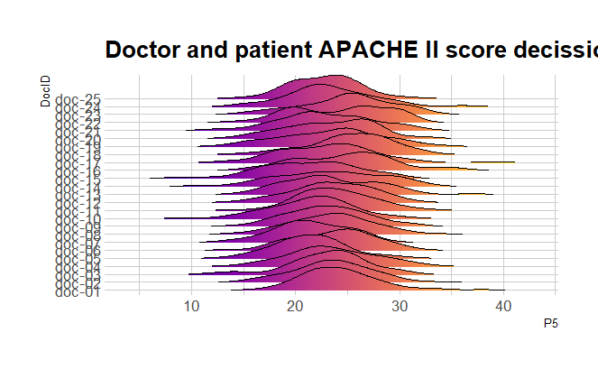

```r
# Plot
ggplot(df_patients_v20220321, aes(x = P5, y = DocID, fill = ..x..)) +
  geom_density_ridges_gradient(scale = 3, rel_min_height = 0.01) +
  scale_fill_viridis(name = "SOFA score at admission", option = "C") +
  labs(title = 'Doctor and patient APACHE II score decission') +
  theme_ipsum() +
    theme(
      legend.position="none",
      panel.spacing = unit(0.1, "lines"),
      strip.text.x = element_text(size = 8)
    )
```

[output not shown]

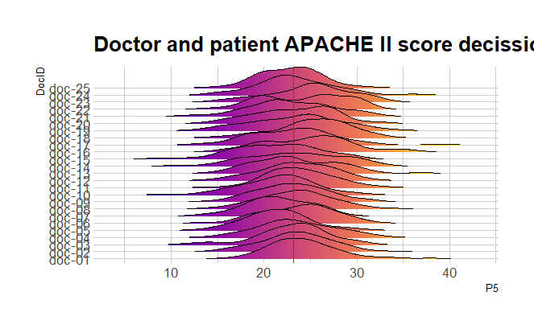

```r
ggplot(df_patients_v20220321, aes(x = P5, y = DocID, fill = ..x..)) +
  geom_density_ridges_gradient(scale = 3, rel_min_height = 0.01) +
  scale_fill_viridis(name = "SOFA score at admission", option = "C") +
  labs(title = 'Doctor and patient APACHE II score decission') +
  geom_vline(xintercept = mean(df_patients_v20220321$P5),color="red")+
  theme_ipsum() +
    theme(
      legend.position="none",
      panel.spacing = unit(0.1, "lines"),
      strip.text.x = element_text(size = 8)
    )
```

[output not shown]

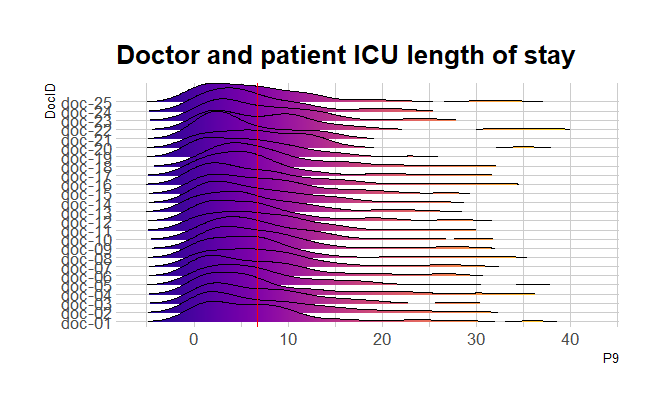

```r
# Plot
ggplot(df_patients_v20220321, aes(x = P9, y = DocID, fill = ..x..)) +
  geom_density_ridges_gradient(scale = 3, rel_min_height = 0.01) +
  scale_fill_viridis(name = "SOFA score at admission", option = "C") +
  labs(title = 'Doctor and patient ICU length of stay') +
  theme_ipsum() +
  geom_vline(xintercept = mean(df_patients_v20220321$P9),color="red")+
    theme(
      legend.position="none",
      panel.spacing = unit(0.1, "lines"),
      strip.text.x = element_text(size = 8)
    )
```

[output not shown]

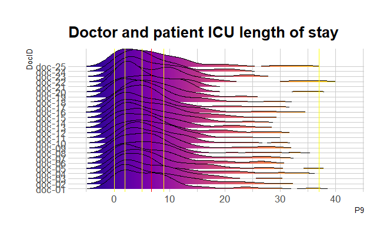

```r
ggplot(df_patients_v20220321, aes(x = P9, y = DocID, fill = ..x..)) +
  geom_density_ridges_gradient(scale = 5, rel_min_height = 0.01) +
  scale_fill_viridis(name = "SOFA score at admission", option = "C") +
  labs(title = 'Doctor and patient ICU length of stay') +
  theme_ipsum() +
  geom_vline(xintercept = mean(df_patients_v20220321$P9),color="red")+
    geom_vline(xintercept = quantile(df_patients_v20220321$P9),color="yellow")+
    theme(
      legend.position="none",
      panel.spacing = unit(0.1, "lines"),
      strip.text.x = element_text(size = 8)
    )
```

## Patient dataset distance matrix

We may say that it is visible that we have subsets of patients which have almost the same recordings.

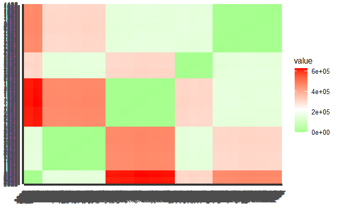

```r
distance <- get_dist(df_patients_v20220321)
fviz_dist(distance, gradient = list(low = "green", mid = "white", high = "red"))
```

# Explore library

this library may be used to further investigate some decission trees for regression or classification in each of the dataset. Just keep in mind which is our target variable.

```r
library(explore)
# df_doctors_v20220321 %>% explore() # same logic should be used if you work with the other datasets
```

# Spearman correlation

Reference: https://statsandr.com/blog/correlation-coefficient-and-correlation-test-in-r/

There are several correlation methods (Run ?cor for more information about the different methods available in the cor() function):

- Pearson correlation is often used for quantitative continuous variables that have a linear relationship
- Spearman correlation (which is actually similar to Pearson but based on the ranked values for each variable rather than on the raw data) is often used to evaluate relationships involving at least one qualitative ordinal variable or two quantitative variables if the link is partially linear

-Kendall’s tau-b which is computed from the number of concordant and discordant pairs is often used for qualitative ordinal variables

```r
# Spearman correlation between 2 variables
cor(df_doctors_v20220321$M4, df_doctors_v20220321$M5,method = "spearman")
```

```
[1] -0.1259813
```

## Variable Importance for Patient dataset

LOS (Length of stay) at ICU is important for the performance of the physicians, also patient status discharge (alive) is important and SOFA score at admission is helping us to understand patient status.

```r
boruta_output <- Boruta(P6~., data=df_patients_v20220321, doTrace=0)
boruta_signif <- getSelectedAttributes(boruta_output, withTentative = TRUE)
print(boruta_signif)
```

```
[1] "DocID" "PtID"  "P1"    "P2"    "P3"    "P5"    "P8"    "P9"
[9] "P10"
```

```r
boruta_output <- Boruta(P9~., data=df_patients_v20220321[,-c(1,2)], doTrace=0)
boruta_signif <- getSelectedAttributes(boruta_output, withTentative = TRUE)
print(boruta_signif)
```

```
[1] "P2"  "P3"  "P5"  "P6"  "P8"  "P10"
```

```r
# Do a tentative rough fix
roughFixMod <- TentativeRoughFix(boruta_output)
boruta_signif <- getSelectedAttributes(roughFixMod)
print(boruta_signif)
```

```
[1] "P2"  "P3"  "P5"  "P6"  "P8"  "P10"
```

```r
# Variable Importance Scores
imps <- attStats(roughFixMod)
imps2 = imps[imps$decision != 'Rejected', c('meanImp', 'decision')]
head(imps2[order(-imps2$meanImp), ])  # descending sort
```

|  | meanImp | decision |
| --- | --- | --- |
| P10 | 14.708437 | Confirmed |
| P6 | 14.285787 | Confirmed |
| P5 | 10.196682 | Confirmed |
| P8 | 7.998015 | Confirmed |
| P3 | 4.460785 | Confirmed |
| P2 | 4.115869 | Confirmed |

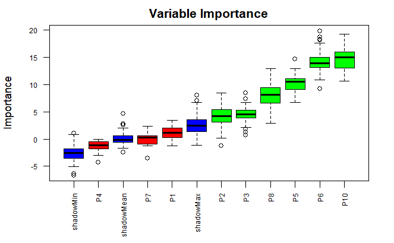

```r
# Plot variable importance
plot(boruta_output, cex.axis=.7, las=2, xlab="", main="Variable Importance")
```

## Random Forest model for patient dataset

here we have considered as our target variable the length of stay (LOS) at ICU. (P9) and analysed which variables are of high importance for this variable.

```r
set.seed(0)
model_rf <- ranger(P9~., data=df_patients_v20220321[,-c(1,2)], mtry = 2, num.trees = 500, write.forest=TRUE, importance = "permutation")
```

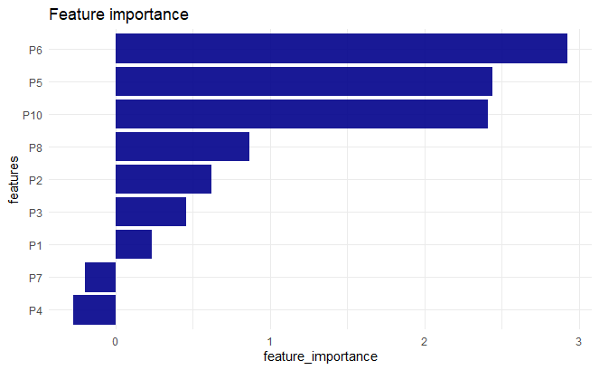

```r
p2<-data.frame(variables = names(importance(model_rf, method = "janitza")),           feature_importance = importance(model_rf, method = "janitza")) %>%
  ggplot(aes(x = feature_importance, y = reorder(variables, X = feature_importance))) +
    geom_bar(stat = "identity",  alpha=0.9, fill="darkblue") +
    labs(y = "features", title = "Feature importance") +
    theme_minimal(base_size = 10)
p2
```

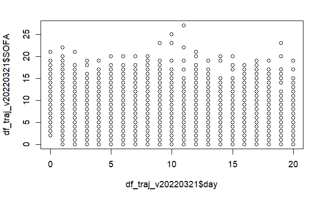

```r
plot(df_traj_v20220321$day,df_traj_v20220321$SOFA)
```

```r
cor(df_traj_v20220321$day,df_traj_v20220321$SOFA)
```

```
[1] -0.1498145
```

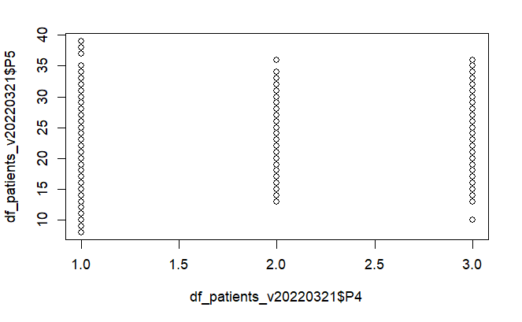

```r
plot(df_patients_v20220321$P4, df_patients_v20220321$P5)
```

```r
cor(df_patients_v20220321[,c(6,7,8,11)])
```

```
             P4          P5          P6           P9
P4  1.000000000  0.09936731  0.03825121 -0.003377003
P5  0.099367310  1.00000000  0.80197518 -0.024320431
P6  0.038251210  0.80197518  1.00000000 -0.032661279
P9 -0.003377003 -0.02432043 -0.03266128  1.000000000
```

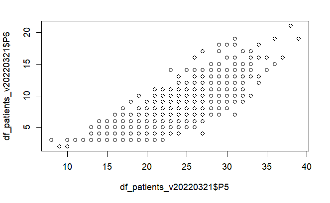

```r
plot(df_patients_v20220321$P5, df_patients_v20220321$P6)
```